# WilloughbyHW10

Bryant Willoughby

2025-11-12

# Problem 1

- Fit a ridge regression model to the `seatpos` data with `hipcenter` as the response and all other variables as predictors. Take care to select an appropriate amount of shrinkage. Use the model to predict the response at the values of the predictors specified in the first question:

Age: 64.8, Weight: 263.7, HtShoes: 181.080, Ht: 178.560, Seated: 91.440, Arm: 35.640, Thigh: 40.950, Leg: 38.790

- Give a discussion on the comparison of the ridge estimates with standard least squares estimates with all predictors

Data (Description): Car drivers like to adjust the seat position for their own comfort. Car designers would find it helpful to know where different drivers will position the seat depending on their size and age. Researchers collected data on 38 drivers.

```r
data(seatpos)
attach(seatpos)
head(seatpos)
```

```
##   Age Weight HtShoes    Ht Seated  Arm Thigh  Leg hipcenter
## 1  46    180   187.2 184.9   95.2 36.1  45.3 41.3  -206.300
## 2  31    175   167.5 165.5   83.8 32.9  36.5 35.9  -178.210
## 3  23    100   153.6 152.2   82.9 26.0  36.6 31.0   -71.673
## 4  19    185   190.3 187.4   97.3 37.4  44.1 41.0  -257.720
## 5  23    159   178.0 174.1   93.9 29.5  40.1 36.9  -173.230
## 6  47    170   178.7 177.0   92.4 36.0  43.2 37.4  -185.150
```

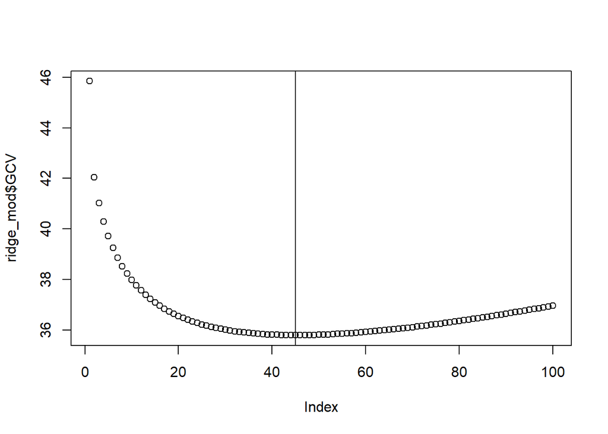

```r
# Ridge regression: choose a reasonable labmda grid
lambda_grid <- seq(0, 50, length.out = 100)
ridge_mod <- lm.ridge(hipcenter ~ ., data = seatpos, lambda = lambda_grid)

# select lambda with GCV method
idx <- which.min(ridge_mod$GCV)
lambda_hat <- ridge_mod$lambda[idx]
plot(ridge_mod$GCV)
abline(v=idx)
```

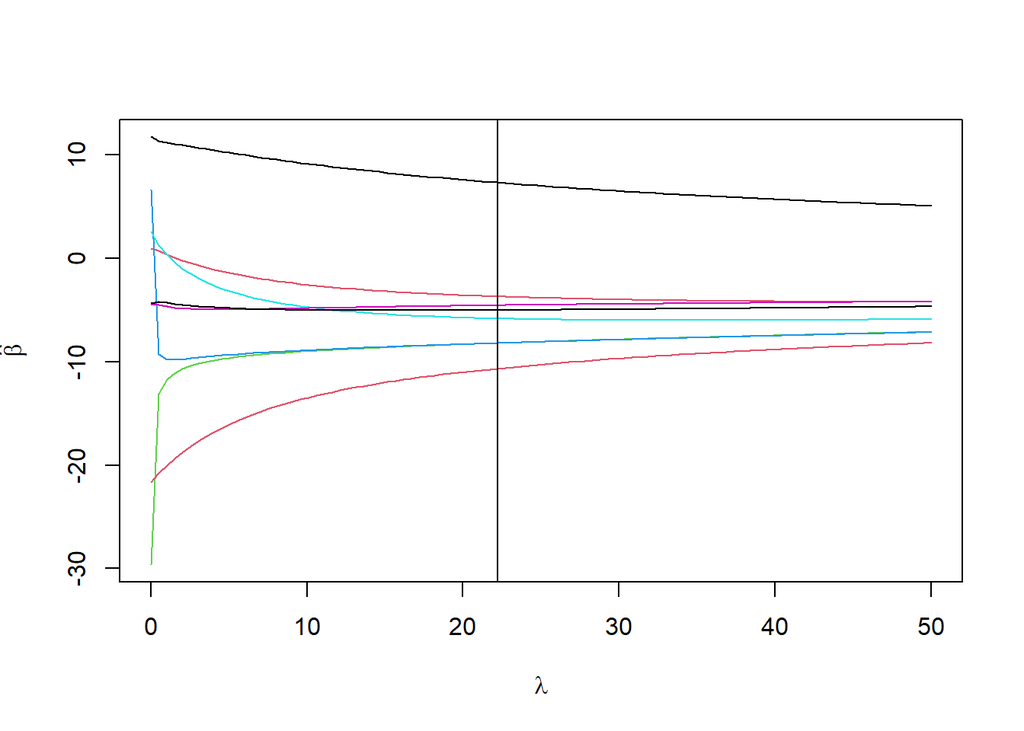

```r
# Plot coefficient paths
matplot(ridge_mod$lambda, t(ridge_mod$coef), type="l", lty=1,
        xlab = expression(lambda), ylab = expression(hat(beta)))
abline(v=lambda_hat)
```

```r
paste("Lambda", round(lambda_hat,3))
```

```
## [1] "Lambda 22.222"
```

```r
# OLS coefficients
OLS_model <- lm(hipcenter ~ ., data = seatpos)
ols_coef <- coef(OLS_model)

# Extract standardized ridge coefficients
b_std <- ridge_mod$coef[, idx]      # standardized slopes
s_x   <- ridge_mod$scales           # predictor SDs
x_m   <- ridge_mod$xm               # predictor means
y_m   <- ridge_mod$ym               # response mean

# Convert ridge coefficients to original scale

# unscale slopes:
b_orig <- b_std / s_x

# unscale intercept:
b0_orig <- y_m - sum(b_orig * x_m)

# combine intercept and slopes:
ridge_coef_orig <- c(b0_orig, b_orig)
names(ridge_coef_orig) <- names(ols_coef)

# Comparison table

coef_compare <- data.frame(
Predictor = names(ols_coef),
OLS = round(ols_coef, 3),
Ridge = round(ridge_coef_orig, 3)
)

coef_compare
```

```
##               Predictor     OLS   Ridge
## (Intercept) (Intercept) 436.432 403.015
## Age                 Age   0.776   0.484
## Weight           Weight   0.026  -0.104
## HtShoes         HtShoes  -2.692  -0.745
## Ht                   Ht   0.601  -0.743
## Seated           Seated   0.534  -1.195
## Arm                 Arm  -1.328  -1.362
## Thigh             Thigh  -1.143  -1.307
## Leg                 Leg  -6.439  -3.167
```

```r
# OLS RMSE
rmse_ols <- rmse(seatpos$hipcenter, OLS_model$fitted.values)

# Ridge RMSE (predictions on original scale)
ridge_fitted <- ridge_mod$ym +
  scale(seatpos[ , -which(names(seatpos) == "hipcenter")],
  center = ridge_mod$xm,
  scale  = ridge_mod$scales) %*%
  ridge_mod$coef[, idx]

rmse_ridge <- rmse(seatpos$hipcenter, ridge_fitted)

# RMSE comparison table

rmse_compare <- data.frame(
Model = c("OLS", "Ridge"),
RMSE  = c(rmse_ols, rmse_ridge)
)

rmse_compare
```

```
##   Model     RMSE
## 1   OLS 32.95203
## 2 Ridge 34.12006
```

```r
# Predict hipcenter for new driver
newdriver <- data.frame(
  Age = 64.8,
  Weight = 263.7,
  HtShoes = 181.080,
  Ht = 178.560,
  Seated = 91.440,
  Arm = 35.640,
  Thigh = 40.950,
  Leg = 38.790
  )

ridge_pred <- ridge_mod$ym +
  scale(newdriver,
  center = ridge_mod$xm,
  scale  = ridge_mod$scales) %*%
  ridge_mod$coef[, idx]

ridge_pred
```

```
##           [,1]
## [1,] -194.7571
```

Ridge regression introduces shrinkage to stabilize coefficient estimates in the presence of collinear predictors. The ridge trace plot indicates the coefficients gradually shrink toward zero as $\lambda$ increases, and the selected tuning parameter ($\lambda \approx$ 22.222) reflects a moderate amount of regularization.

Ridge regression attempts to shrink all of the slope coefficients toward zero, but the amount of shrinkage differs across predictors. The `Leg` and `HtShoes` variables show the largest change in magnitude, indicating that their OLS estimates were heavily influenced by collinearity.

In contrast, predictors like `Weight`, `Ht`, and `Seated` change less in magnitude, while their signs differ, suggesting that their underlying effects were relatively weak and unstable.

Finally, using the ridge model with the selected $\lambda$, the predicted hipcenter for the given driver profile is approximately **-194.76**, reflecting the regularized contribution of all predictors.

# Problem 2

Take the `fat` data and use the percentage of body fat, `siri`, as the response and the other variables, except `brozek` and `density` as potential predictors. Remove every tenth observation from the data for use as a test sample. Use the remaining data to build the following models:

- Linear regression with all predictors
- Ridge regression
- Lasso

Use the models you find to predict the response in the test sample. Make a report on the performances of the models.

Data (Description): Age, weight, height, and 10 body circumference measurements are recorded for 252 men. Each man’s percentage of body fat was accurately estimated by an underwater weighing technique.

```r
data(fat)
attach(fat)
head(fat)
```

```
##   brozek siri density age weight height adipos  free neck chest abdom   hip
## 1   12.6 12.3  1.0708  23 154.25  67.75   23.7 134.9 36.2  93.1  85.2  94.5
## 2    6.9  6.1  1.0853  22 173.25  72.25   23.4 161.3 38.5  93.6  83.0  98.7
## 3   24.6 25.3  1.0414  22 154.00  66.25   24.7 116.0 34.0  95.8  87.9  99.2
## 4   10.9 10.4  1.0751  26 184.75  72.25   24.9 164.7 37.4 101.8  86.4 101.2
## 5   27.8 28.7  1.0340  24 184.25  71.25   25.6 133.1 34.4  97.3 100.0 101.9
## 6   20.6 20.9  1.0502  24 210.25  74.75   26.5 167.0 39.0 104.5  94.4 107.8
##   thigh knee ankle biceps forearm wrist
## 1  59.0 37.3  21.9   32.0    27.4  17.1
## 2  58.7 37.3  23.4   30.5    28.9  18.2
## 3  59.6 38.9  24.0   28.8    25.2  16.6
## 4  60.1 37.3  22.8   32.4    29.4  18.2
## 5  63.2 42.2  24.0   32.2    27.7  17.7
## 6  66.0 42.0  25.6   35.7    30.6  18.8
```

```r
# Remove columns brozek and density using base R
fat <- fat[, !(names(fat) %in% c("brozek", "density"))]

# Train/test split: every 10th observation
test_idx <- seq(10, nrow(fat), by = 10)
fat_test  <- fat[test_idx, ]
fat_train <- fat[-test_idx, ]

# Build matrices
X_train <- as.matrix(fat_train[, names(fat_train) != "siri"])
y_train <- fat_train$siri

X_test  <- as.matrix(fat_test[, names(fat_test) != "siri"])
y_test  <- fat_test$siri
```

```r
# SLR
ols_mod <- lm(siri ~ ., data = fat_train)
# summary(ols_mod)
coef_ols <- coef(ols_mod)
ols_pred <- predict(ols_mod, fat_test)

rmse_ols <- rmse(y_test, ols_pred)
paste("RMSE:", round(rmse_ols,3))
```

```
## [1] "RMSE: 1.132"
```

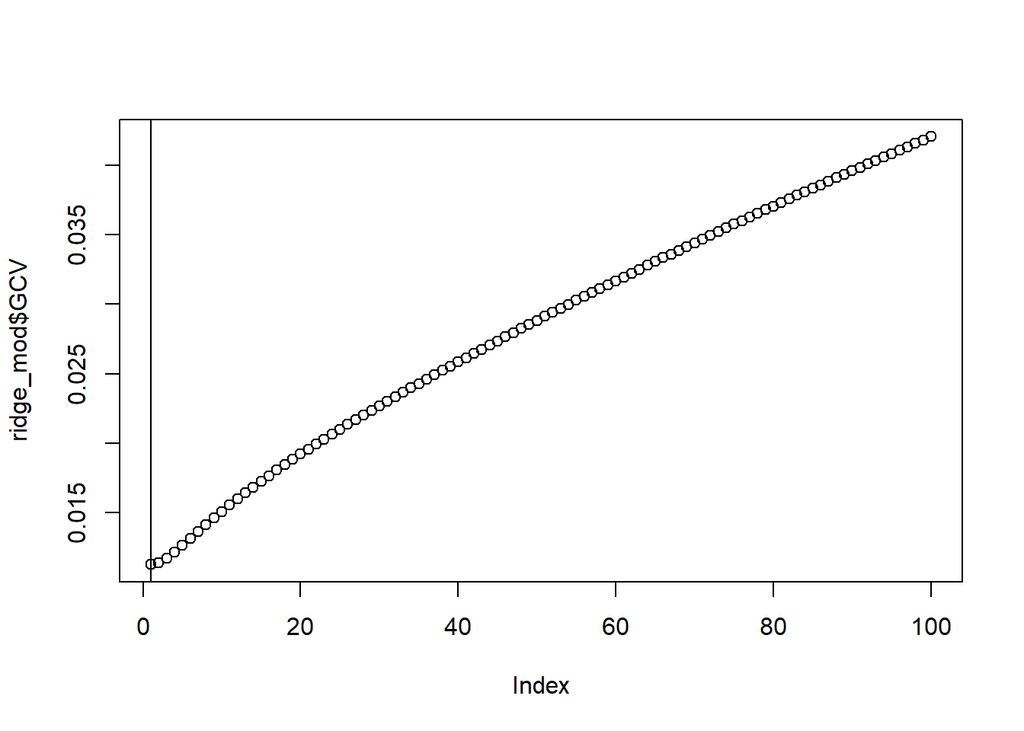

```r
# Ridge regression: choose a reasonable labmda grid
lambda_grid <- seq(0, 50, length.out = 100)
ridge_mod <- lm.ridge(siri ~ ., data = fat_train, lambda = lambda_grid)

# select lambda with GCV method
idx <- which.min(ridge_mod$GCV)
lambda_hat <- ridge_mod$lambda[idx]
plot(ridge_mod$GCV)
abline(v=idx)
```

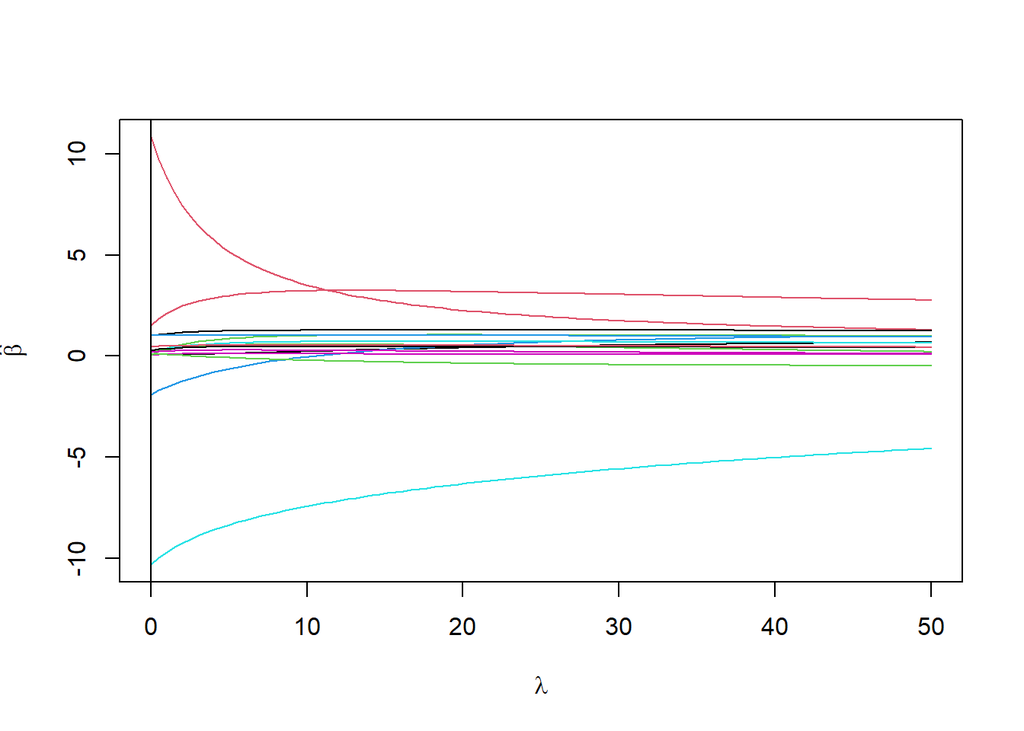

```r
# Plot coefficient paths
matplot(ridge_mod$lambda, t(ridge_mod$coef), type="l", lty=1,
        xlab = expression(lambda), ylab = expression(hat(beta)))
abline(v=lambda_hat)
```

```r
paste("Lambda:", round(lambda_hat,3))
```

```
## [1] "Lambda: 0"
```

```r
# Note: lambda = 0 --> same as OLS

# Extract standardized ridge coefficients
b_std <- ridge_mod$coef[, idx]      # standardized slopes
s_x   <- ridge_mod$scales           # predictor SDs
x_m   <- ridge_mod$xm               # predictor means
y_m   <- ridge_mod$ym               # response mean

# Convert ridge coefficients to original scale

# unscale slopes:
b_orig <- b_std / s_x

# unscale intercept:
b0_orig <- y_m - sum(b_orig * x_m)

# coefficients
coef_ridge0 <- c(b0_orig, b_orig)

# ridge prediction
ridge_pred <- as.vector(b0_orig + X_test %*% b_orig)
rmse_ridge <- rmse(y_test, ridge_pred)
paste("RMSE:", round(rmse_ridge,3))
```

```
## [1] "RMSE: 1.132"
```

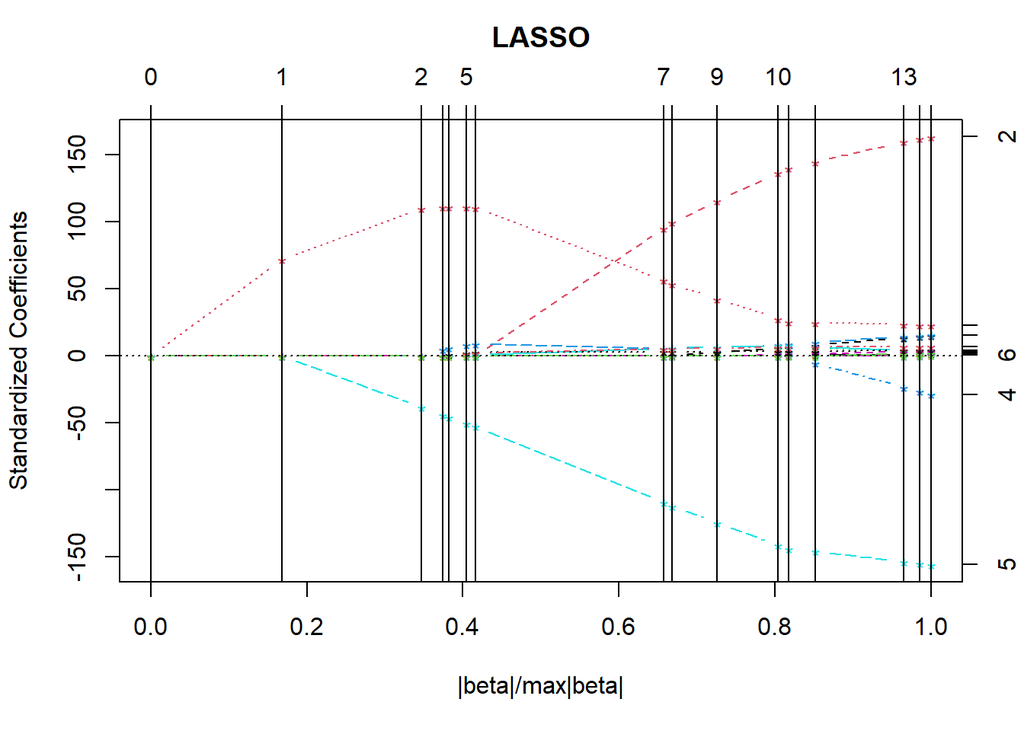

```r
# Fit lasso model
lasso_mod <- lars(X_train, y_train, type = "lasso")
plot(lasso_mod)
```

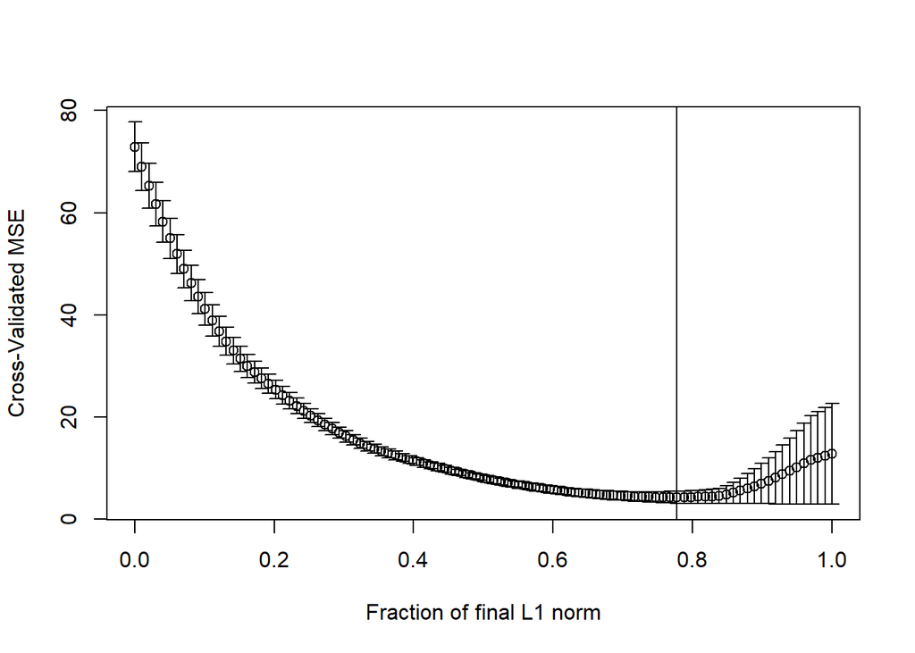

```r
# choose lambda
set.seed(123) # ensures reproducible CV
cvlmod <- cv.lars(X_train, y_train, type = "lasso")
lambda <- cvlmod$index[which.min(cvlmod$cv)]
abline(v=lambda)
```

```r
paste("Lambda:", round(lambda, 3))
```

```
## [1] "Lambda: 0.778"
```

```r
# LASSO coefficients (slopes only)
lasso_coef <- coef(lasso_mod, s = lambda, mode = "fraction")

# Means of training predictors and response
xbar <- lasso_mod$meanx
ybar <- lasso_mod$mu

# Compute intercept manually
lasso_intercept <- ybar - sum(xbar * lasso_coef)

# Prediction function
lasso_pred <- as.vector(lasso_intercept + X_test %*% lasso_coef)

# RMSE
rmse_lasso <- rmse(y_test, lasso_pred)
rmse_lasso
```

```
## [1] 1.133336
```

```r
# Combine into table
coef_compare <- data.frame(
  Predictor = names(coef_ols),
  OLS = round(coef_ols, 4),
  Ridge0 = round(coef_ridge0, 4),
  LASSO = round(c(lasso_mod$mu, lasso_coef), 4)
)

coef_compare
```

```
##               Predictor      OLS   Ridge0   LASSO
## (Intercept) (Intercept) -12.5919 -12.5919 19.1802
## age                 age   0.0080   0.0080  0.0000
## weight           weight   0.3630   0.3630  0.2878
## height           height   0.0490   0.0490  0.0789
## adipos           adipos  -0.5140  -0.5140  0.0000
## free               free  -0.5648  -0.5648 -0.4913
## neck               neck   0.0165   0.0165  0.0000
## chest             chest   0.1202   0.1202  0.0377
## abdom             abdom   0.1401   0.1401  0.2003
## hip                 hip   0.0062   0.0062  0.0000
## thigh             thigh   0.1951   0.1951  0.0959
## knee               knee   0.1066   0.1066  0.2023
## ankle             ankle   0.1251   0.1251  0.0340
## biceps           biceps   0.0962   0.0962  0.0742
## forearm         forearm   0.2308   0.2308  0.2068
## wrist             wrist   0.1393   0.1393  0.0000
```

```r
rmse_compare <- data.frame(
Model = c("OLS", "Ridge", "Lasso"),
RMSE  = c(rmse_ols, rmse_ridge, rmse_lasso)
)

rmse_compare
```

```
##   Model     RMSE
## 1   OLS 1.131529
## 2 Ridge 1.131529
## 3 Lasso 1.133336
```

Across the three models, OLS and ridge produce identical coefficient estimates because the GCV–selected ridge penalty is $\lambda = 0$. This means ridge regression reduces exactly to the OLS solution, so no shrinkage or stabilization occurs. In contrast, the lasso model shrinks several coefficients noticeably toward zero and sets multiple predictors—such as `age`, `adipos`, `neck`, `hip`, and `wrist`—exactly to zero, indicating that these variables contribute little unique predictive value beyond the remaining predictors.

Ridge regression uses an L2 penalty, which continuously shrinks coefficients toward zero but cannot set them exactly to zero. This is why every predictor remains in the ridge model—even those with very small estimated effects. In contrast, the L1 penalty in lasso produces exact zeros, performing true variable selection.

Among the non-zero lasso coefficients, some are moderately reduced in magnitude relative to OLS (e.g., `weight`, `thigh`, `biceps`, `forearm`), while others increase slightly (`height`, `abdom`, `knee`). This reflects the lasso’s bias–variance trade-off: coefficients may shrink toward zero but can also adjust upward when the penalty selects a more parsimonious subset of predictors.